# Differential expression

2017-07-05

```r
library(DESeq2)
library(bcbioRnaseq)

downloads()

source("setup.R") # modify parameters before exec this line
# Contrast
# 1. Design matrix parameter.
# 2. Numerator for LFC (expt).
# 3. Denominator for LFC (control).
# @seealso [DESeq2::results()]
contrast <- c("gender", "male", "female")

# Design formula
design <- formula(~ gender+genotype+treatment) # change to desire column

# Significance cutoffs
alpha <- 0.05
lfc <- 1
```

# Overview

- Primary Investigator:
- Researcher:
- Experiment:

```r
> metadata_table(bcb)
```

[output not shown]

```r
> txi <- bcbio(bcb, "tximport")
> coldata <- colData(bcb)
> coldata$treatment = relevel(coldata$treatment, ref = "untreated")
> coldata$genotype = relevel(coldata$genotype, ref = "wt")
> coldata$gender = relevel(coldata$gender, ref = "male")
>
> ddsde <- DESeqDataSetFromTximport(txi = txi, colData = coldata, design = design)
> ddsde <- DESeq(ddsde)
> rld <- rlog(ddsde)
> save_data(ddsde, dir = data_out)
> resultsNames(ddsde)
> sizeFactors(ddsde)
```

# Contrasts to look at

[output not shown]

```r
> library(dplyr)
> sample_counts = colData(bcb) %>% as.data.frame() %>% group_by(gender, genotype,
+     treatment) %>% summarise(count = n())
```

[output not shown]

```r
> knitr::kable(sample_counts)
```

[output not shown]

# Clustering

The samples separate by gender and we can see the batches of untreated male samples cluster together, so the gender-specific differences are stronger than any batch effect that might be occuring. That is a good sign for trying to find differences between the female and male samples.

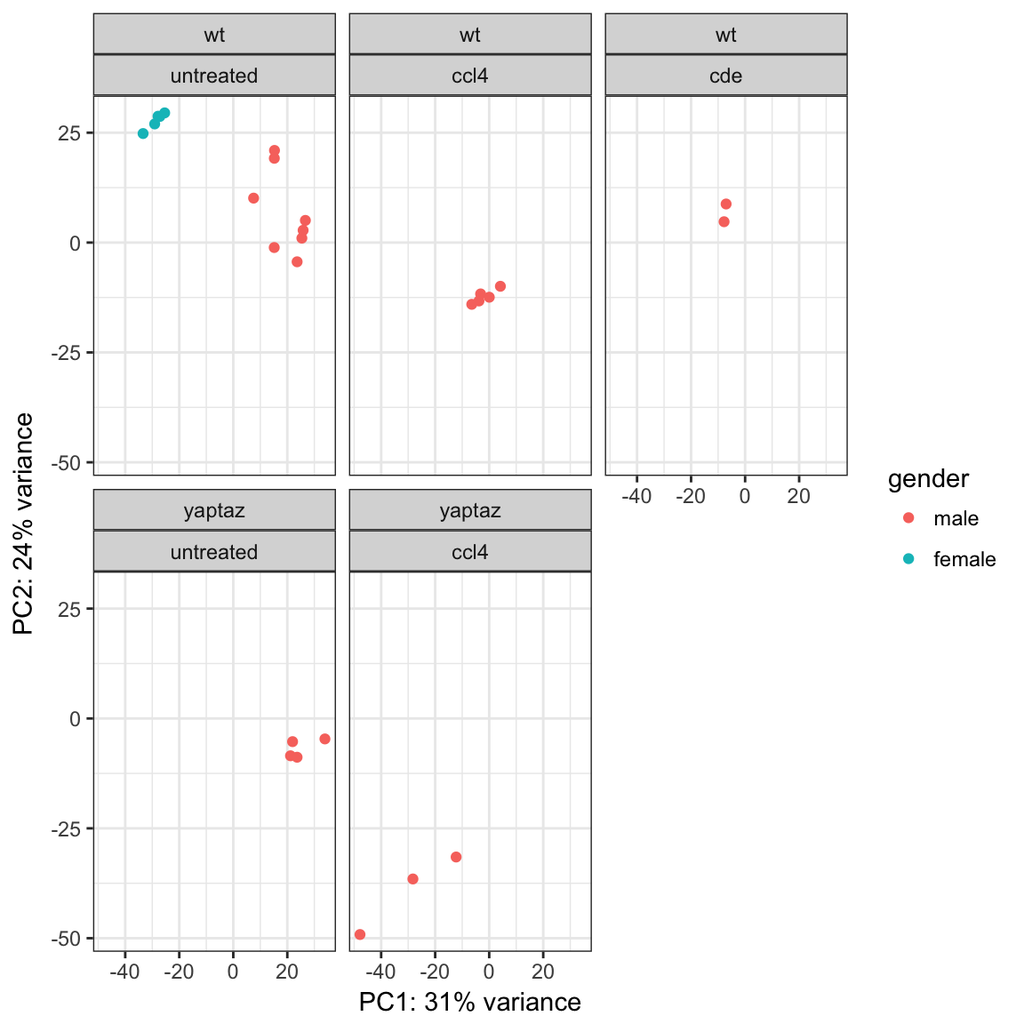

```r
> vst = varianceStabilizingTransformation(ddsde)
> pca_loadings = function(object, ntop = 500) {
+     rv <- matrixStats::rowVars(assay(object))
+     select <- order(rv, decreasing = TRUE)[seq_len(min(ntop, length(rv)))]
+     pca <- prcomp(t(assay(object)[select, ]))
+     percentVar <- pca$sdev^2/sum(pca$sdev^2)
+     names(percentVar) = colnames(pca$x)
+     pca$percentVar = percentVar
+     return(pca)
+ }
> pc = pca_loadings(vst)
> comps = data.frame(pc$x)
> comps$description = rownames(comps)
> coldata$description = rownames(coldata)
> library(dplyr)
> comps = comps %>% left_join(as.data.frame(coldata), by = "description")
> comps$batch = ifelse(grepl("_S", comps$description), "second", "first")
> comps$gender_batch = paste(comps$gender, comps$batch, sep = "_")
> colorby = "gender"
> pca_plot = function(comps, nc1, nc2, colorby) {
+     c1str = paste0("PC", nc1)
+     c2str = paste0("PC", nc2)
+     if (!(c1str %in% colnames(comps) && c2str %in% colnames(comps))) {
+         warning("Higher order components not found, skipping plotting.")
+         return(NA)
+     }
+     ggplot(comps, aes_string(c1str, c2str, color = colorby)) + geom_point() +
+         theme_bw() + facet_wrap(~genotype + treatment) + xlab(paste0(c1str,
+         ": ", round(pc$percentVar[nc1] * 100), "% variance")) + ylab(paste0(c2str,
+         ": ", round(pc$percentVar[nc2] * 100), "% variance"))
+ }
> pca_plot(comps, 1, 2, "gender")
```

# Effect of gender

We fit a model that takes into account the effect of genotype, the effect of treatment and the effect of gender and look at the effect of gender, controlling for all of the other effects.

# Alpha level (FDR) cutoffs

```r
> contrast <- c("gender", "female", "male")
> gender <- results(ddsde, contrast = c("gender", "female", "male")) %>% as.data.frame() %>%
+     tibble::rownames_to_column(var = "ensgene") %>% left_join(as.data.frame(rowData(bcb)),
+     by = "ensgene")
> gendersig <- subset(gender, padj < 0.05)
> gendersighigh <- subset(gender, padj < 0.05 & abs(log2FoldChange) > 1)
```

There are 1440 genes that vary with gender at FDR < 0.05, and there are 1083 that have a fold change greater than two-fold.

As a sanity check, we should be seeing Xist as higher in the female. We can see that is true below (positive log2FoldChange is higher in the females for this comparison).

```r
> subset(gender, symbol == "Xist")
```

|  | ensgene | baseMean | log2FoldChange | lfcSE | stat | pvalue | padj | symbol | chr | start | end | strand | biotype | description | broad_class |
| --- | --- | --- | --- | --- | --- | --- | --- | --- | --- | --- | --- | --- | --- | --- | --- |
| 28253 | ENSMUSG00000086503 | 2361.14 | 8.614659 | 1.057843 | 8.143607 | 0 | 0 | Xist | X | 103460375 | 103483217 | -1 | lincRNA | inactive X specific transcripts [Source:MGI Symbol;Acc:MGI:98974] | noncoding |

# Plots

## Mean average (MA)

An MA plot compares transformed counts on `M` (log ratio) and `A` (mean average) scales [@Yang:2002ty].

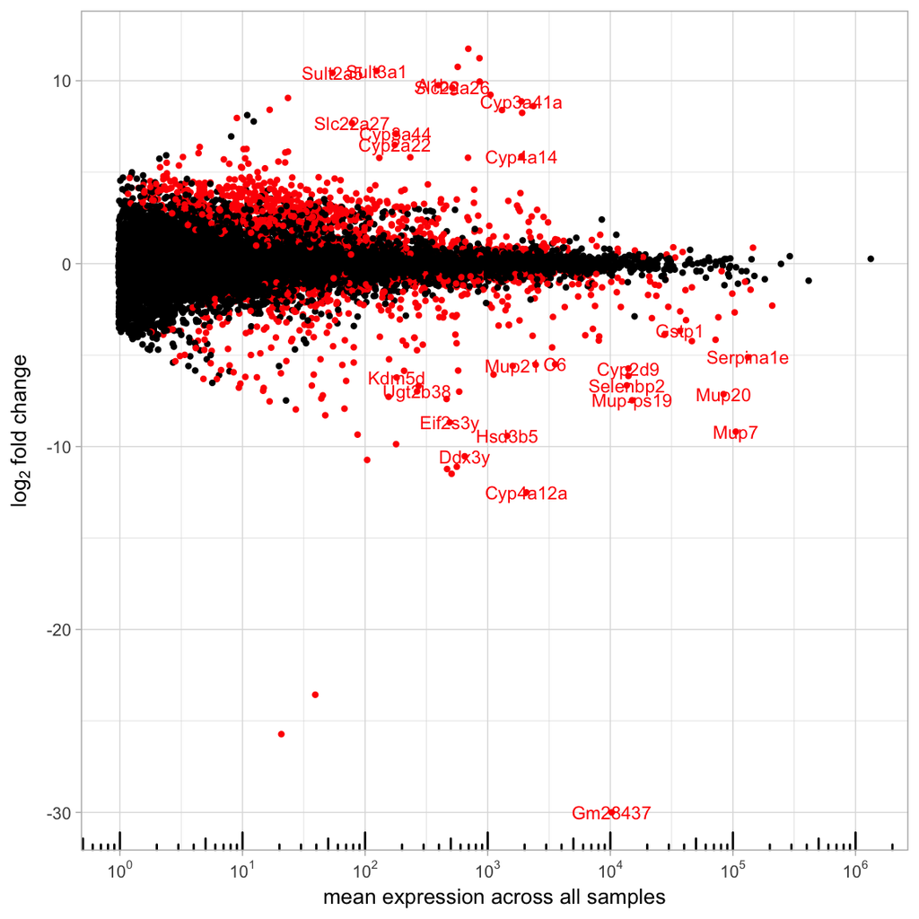

```r
> label = gender %>% arrange(padj) %>% head(25)
> plot_ma(gender, label_points = label$symbol) + theme_light(base_size = 10)
```

## Volcano

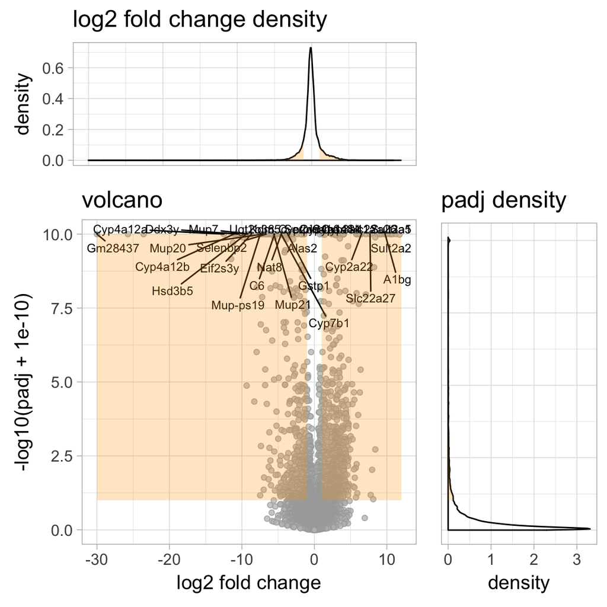

```r
> res = results(ddsde, contrast = c("gender", "female", "male"))
> plot_volcano(bcb, res = res, lfc = lfc)
```

## Heatmap

This plot shows only differentially expressed genes on a per-sample basis. We have scaled the data by row and used the `ward.D2` method for clustering [@WardJr:1963eu].

[figure not shown]

```r
> plot_deg_heatmap(bcb, res = res, dt = rld, lfc = lfc)
```

Below is a heatmap of just the untreated, wildtype samples, so just looking at the affect of gender.

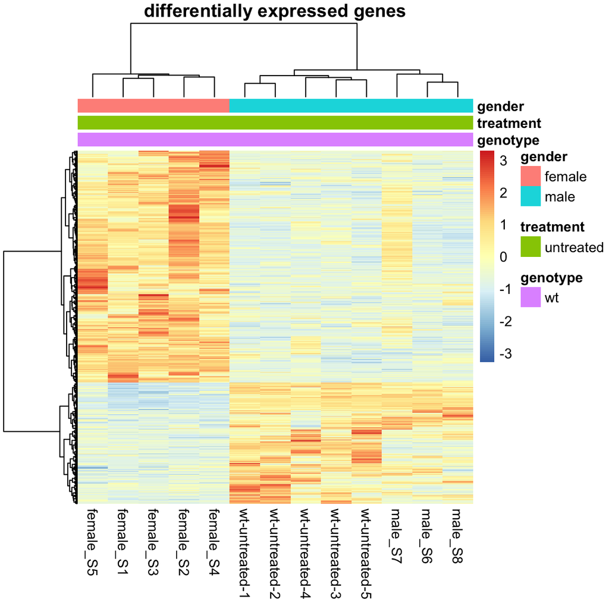

```r
> untreated = bcb[, colData(bcb)$treatment == "untreated" & colData(bcb)$genotype ==
+     "wt"]
> untreateddds = ddsde[, colData(bcb)$treatment == "untreated" & colData(bcb)$genotype ==
+     "wt"]
> rld = rlog(untreateddds)
> plot_deg_heatmap(untreated, res = res, dt = rld, lfc = lfc)
```

```r
> tpm = txi$abundance %>% as.data.frame() %>% tibble::rownames_to_column("ensgene")
> counts = txi$counts %>% as.data.frame() %>% tibble::rownames_to_column("ensgene")
> readr::write_csv(tpm, "results/tpm.csv.gz")
> readr::write_csv(counts, "results/counts.csv.gz")
```

## GSEA

```r
> orgdb = "org.Mm.eg.db"
> library(dplyr)
> library(clusterProfiler)
> library(orgdb, character.only = TRUE)
> library(biomaRt)
> biomart_dataset = "mmusculus_gene_ensembl"
> keggname = "mmu"
> mart = biomaRt::useMart(biomart = "ensembl", dataset = biomart_dataset)
> symbols = biomaRt::getBM(attributes = c("ensembl_gene_id", "mgi_symbol"), mart = mart)
> entrez = biomaRt::getBM(attributes = c("ensembl_gene_id", "entrezgene"), mart = mart)
> entrezsymbol = biomaRt::getBM(attributes = c("mgi_symbol", "entrezgene"), mart = mart)
> entrezsymbol$entrezgene = as.character(entrezsymbol$entrezgene)
> entrez$entrezgene = as.character(entrez$entrezgene)
>
> summarize_cp = function(res, comparison) {
+     summaries = data.frame()
+     for (ont in names(res)) {
+         ontsum = summary(res[[ont]])
+         ontsum$ont = ont
+         summaries = rbind(summaries, ontsum)
+     }
+     summaries$comparison = comparison
+     return(summaries)
+ }
>
> gsea_cp = function(res, comparison) {
+     res = res %>% as.data.frame() %>% tibble::rownames_to_column("ensembl_gene_id") %>%
+         left_join(entrez, by = "ensembl_gene_id") %>% filter(!is.na(entrezgene)) %>%
+         filter(!is.na(log2FoldChange)) %>% filter(!is.na(lfcSE))
+     fccol = ifelse("lfcMLE" %in% colnames(res), "lfcMLE", "log2FoldChange")
+     lfc = data.frame(res)[, fccol]
+     lfcse = data.frame(res)[, "lfcSE"]
+     genes = lfc/lfcse
+     names(genes) = res$entrezgene
+     genes = genes[order(genes, decreasing = TRUE)]
+     cc = gseGO(genes, ont = "CC", OrgDb = orgdb, nPerm = 500, pvalueCutoff = 1,
+         pAdjustMethod = "BH", verbose = TRUE)
+     mf = gseGO(genes, ont = "MF", OrgDb = orgdb, nPerm = 500, pvalueCutoff = 1,
+         pAdjustMethod = "BH", verbose = TRUE)
+     bp = gseGO(genes, ont = "bp", OrgDb = orgdb, nPerm = 500, pvalueCutoff = 1,
+         pAdjustMethod = "BH", verbose = TRUE)
+     genes = data.frame(res)[, fccol]
+     names(genes) = res$entrezgene
+     genes = genes[order(genes, decreasing = TRUE)]
+     genes = genes[!is.na(genes)]
+     kg = gseKEGG(geneList = genes, organism = keggname, nPerm = 500, pvalueCutoff = 1,
+         verbose = TRUE)
+     if (orgdb == "org.Hs.eg.db") {
+         do = summary(gseDO(geneList = genes, nPerm = 500, pvalueCutoff = 1,
+             pAdjustMethod = "BH", verbose = TRUE))
+         do$ont = "DO"
+         all = list(mf = mf, cc = cc, bp = bp, kg = kg, do = do)
+     } else {
+         all = list(mf = mf, cc = cc, bp = bp, kg = kg)
+     }
+     all[["summary"]] = summarize_cp(all, comparison)
+     return(all)
+ }
>
> convert_core_ids = function(res) {
+     res = res %>% mutate(geneID = strsplit(as.character(geneID), "/")) %>% tidyr::unnest(geneID) %>%
+         left_join(entrezsymbol, by = c(geneID = "entrezgene")) %>% group_by(ID,
+         Description, GeneRatio, BgRatio, pvalue, p.adjust, qvalue, Count, ont,
+         comparison) %>% summarise(geneID = paste(geneID, collapse = "/"), symbol = paste(mgi_symbol,
+         collapse = "/"))
+     return(res)
+ }
> direction_breakdown = function(res, deseq2res) {
+     ocols = colnames(res)
+     deseq2res = deseq2res %>% as.data.frame() %>% tibble::rownames_to_column() %>%
+         dplyr::select(log2FoldChange, rowname)
+     ids = res %>% mutate(symbol = strsplit(as.character(symbol), "/")) %>% tidyr::unnest(symbol) %>%
+         left_join(symbols, by = c(symbol = "mgi_symbol")) %>% left_join(deseq2res,
+         by = c(ensembl_gene_id = "rowname")) %>% mutate(direction = ifelse(log2FoldChange >
+         0, "up", "down"))
+     ids = ids[, c(ocols, "direction")]
+     ids = ids %>% group_by(ID, Description, GeneRatio, BgRatio, pvalue, p.adjust,
+         qvalue, Count, ont, pvalue, p.adjust, qvalue, comparison, direction) %>%
+         summarise(symbols = paste(symbol, collapse = "/"))
+     return(ids)
+ }
> signal_to_noise = function(res) {
+     res = res %>% as.data.frame() %>% tibble::rownames_to_column("ensembl_gene_id") %>%
+         left_join(entrez, by = "ensembl_gene_id") %>% filter(!is.na(entrezgene)) %>%
+         filter(!is.na(log2FoldChange)) %>% filter(!is.na(lfcSE))
+     fccol = ifelse("lfcMLE" %in% colnames(res), "lfcMLE", "log2FoldChange")
+     lfc = data.frame
+     lfcse = data.frame(res)[, "lfcSE"]
+     genes = lfc/lfcse
+     names(genes) = res$entrezgene
+     genes = genes[order(genes, decreasing = TRUE)]
+     return(genes)
+ }
> convert_gsea_ids = function(res, entrezsymbol) {
+     res %>% mutate(geneID = strsplit(as.character(core_enrichment), "/")) %>%
+         tidyr::unnest(geneID) %>% left_join(entrezsymbol, by = c(geneID = "entrezgene")) %>%
+         group_by(ID, Description, setSize, enrichmentScore, NES, pvalue, p.adjust,
+             qvalues, rank, leading_edge, core_enrichment, ont, comparison) %>%
+         summarise(geneID = paste(geneID, collapse = "/"), symbol = paste(mgi_symbol,
+             collapse = "/"))
+ }
>
> gender = data.frame(gender)
> rownames(gender) = gender$ensgene
> gender_gsea = gsea_cp(gender, "gender-effect")
> gender_gsea_res = convert_gsea_ids(gender_gsea$summary, entrezsymbol)
> dir.create("results/gsea")
> readr::write_csv(gender_gsea_res, "results/gsea/gender-gsea-results.csv")
```

# File downloads

The results are saved as gzip-compressed comma separated values (CSV). Gzip compression is natively supported on [macOS][] and Linux-based operating systems. If you’re running Windows, we recommend installing [7-Zip][]. CSV files can be opened in [Excel][] or [RStudio][].

## Count matrices

- `tpm.csv.gz`: Transcripts per million, scaled by effective transcript length and library size, suitable for plotting.
- `counts.csv.gz`: Only use to perform a new differential expression analysis. These counts will vary across samples due to differences in sequencing depth, and have not been normalized. Do not use this file for plotting genes.

## Differentially expressed genes (DEG)

For all tables, a positive log2FoldChange is higher in the female samples than the male samples.

DEG tables are sorted by BH-adjusted P value, and contain the following columns:

- `ensembl_gene_id`: [Ensembl](http://useast.ensembl.org/Mus_musculus/Info/Index) gene identifier.
- `base_mean`: Mean of the normalized counts per gene for all samples.
- `log2_fold_change`: log2 fold change.
- `lfc_se`: log2 standard error.
- `stat`: Wald statistic.
- `pvalue`: Walt test *P* value.
- `padj`: BH adjusted Wald test *P* value (corrected for multiple comparisons; FDR).
- `external_gene_name`: [Ensembl](http://useast.ensembl.org/Mus_musculus/Info/Index) name (a.k.a. symbol).
- `description`: [Ensembl](http://useast.ensembl.org/Mus_musculus/Info/Index) description.
- `gene_biotype`: [Ensembl](http://useast.ensembl.org/Mus_musculus/Info/Index) biotype (e.g. `protein_coding`).

## GSEA

- gender-gsea-results.csv: GSEA results for the gender differences.

```r
> res_tbl <- res_tables(bcb, res = res, lfc = lfc, dir = res_out)
```

```
## res differential expression tables
## - 47729 gene annotations
## - cutoffs applied:
##     - alpha: 0.1
##     - lfc:   1 (tables only)
## - gene detection:
##     - base mean > 0: 30598 genes
##     - base mean > 1: 18999 genes
## - pass cutoffs:
##     - alpha:    2053 genes
##     - lfc up:   924 genes
##     - lfc down: 482 genes
## - []():
##     All genes, sorted by [Ensembl][] identifier.
## - []():
##     Genes that pass the alpha (FDR) cutoff.
## - []():
##     Upregulated DEG; positive log2 fold change.
## - []():
##     Downregulated DEG; negative log2 fold change.
```

```r
> save_data(res_tbl, dir = data_out)
```

# Methods

RNA-seq counts were generated by bcbio-nextgen and bcbioRnaseq using [salmon](https://combine-lab.github.io/salmon/) [@salmon]. Counts were imported into [R](https://www.r-project.org/) using [tximport](https://bioconductor.org/packages/release/bioc/html/tximport.html) [@tximport] and [DESeq2](https://bioconductor.org/packages/release/bioc/html/DESeq2.html) [@DESeq2]. Gene annotations were obtained from [Ensembl](http://useast.ensembl.org/Mus_musculus/Info/Index). Plots were generated by [ggplot2](http://ggplot2.org/) [@ggplot2]. Heatmaps were generated by [pheatmap](https://cran.r-project.org/web/packages/pheatmap/index.html) [@pheatmap].